# Social Network Analysis

##### **1.3.6. Components & Cutpoints**

```r
# Student #13 is a cutpoint (articulation) both in the Friends and in the WorkWith networks. The removal of this individual would make students 18 and 25 alienated from the rest of the class. It is crucial that attention be given to students 18 and 25.
# It is a good sign there there is not cutpoint in the GetOn network.
# It is interesting that a number of students declared to "get on with" students 18 and 25, but these two students only nominated each other in this question.

articulation.points(f) # student 13
```

```
## + 1/29 vertex, named, from 3163424:
## [1] 13
```

```r
articulation.points(w) # student 13
```

```
## + 1/29 vertex, named, from 3164454:
## [1] 13
```

```r
articulation.points(g) # none
```

```
## + 0/29 vertices, named, from 3164454:
```

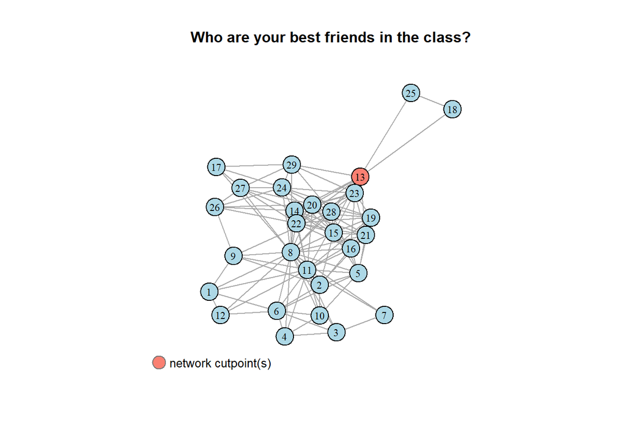

```r
# Friends
set.seed(77)
x <- f
V(x)$color = ifelse(V(x) %in% articulation_points(x), "salmon", "lightblue")
plot(as.undirected(x), layout=layout.fruchterman.reingold)
title("Who are your best friends in the class?", cex.main=1, col.main="black")
legend(x=-1.5, y=-1.1, c("network cutpoint(s)"), pch=21,col="#777777", pt.bg=c("salmon"), pt.cex=2, cex=.8, bty="n", ncol=1)
```

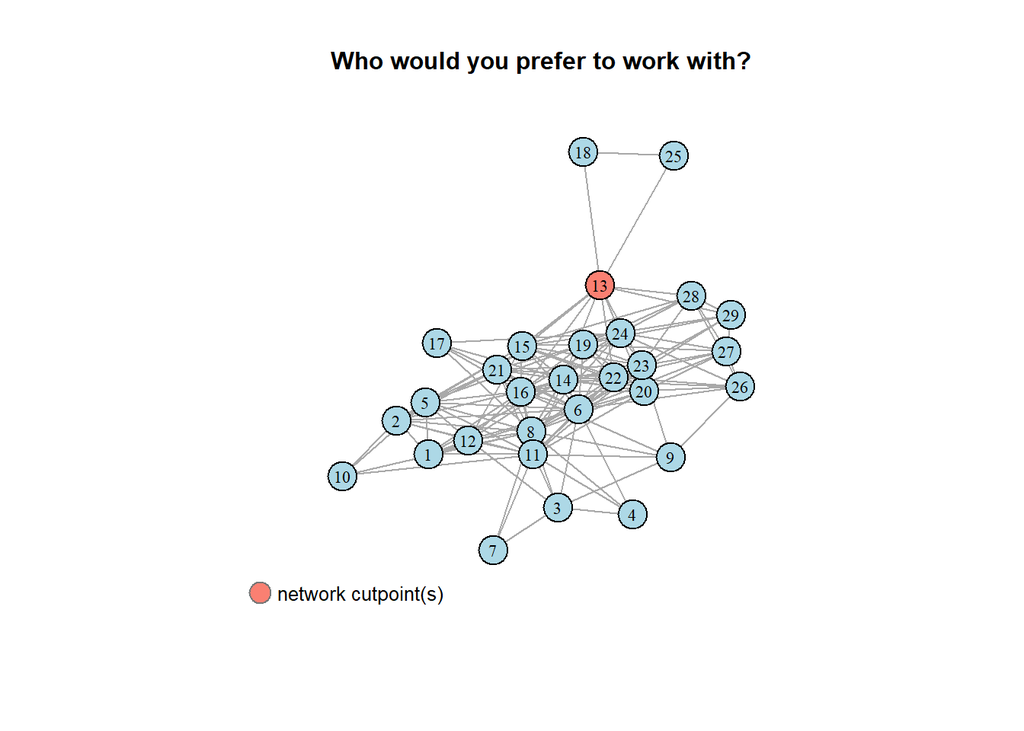

```r
# Work with
set.seed(77)
x <- w
V(x)$color = ifelse(V(x) %in% articulation_points(x), "salmon", "lightblue")
plot(as.undirected(x), layout=layout.fruchterman.reingold)
title("Who would you prefer to work with?", cex.main=1, col.main="black")
legend(x=-1.5, y=-1.1, c("network cutpoint(s)"), pch=21,col="#777777", pt.bg=c("salmon"), pt.cex=2, cex=.8, bty="n", ncol=1)
```

#### **1.4. Analysis**

Gender plays a huge role on how groups and friendships are formed in this class - a dynamic not too uncommon among young (in this case 7th grade) students. But I would be cautious to forcefully promote “a gender mix” in this class. Grouping students from opposite sides of these networks could become a stressful experience to them. Instead, I would suggest starting with milder interventions - mixing boys and girls (and other disconnected students), but not at random: keeping an “integrating” student in the group could help things flow more smoothly among “non-friends”.

It was worrying to see students 18 and 25 “segregated” in the Friends and WorkWith networks. These students seem to need a lot of assistance to better bond with the rest of the class. As a partial relief, these same students are better integrated in the GetOn network - which suggests that there is likely no “animosity” against them in this class.

Inspecting the GetOn graph a little closer, we will see that a lot of students said they “get on with” students 18 and 25 - but these two students “do not get on with” anybody except with each other. Perhaps they fear rejection and self-isolate. Student 13 influence could be used to promote the integration of these students into the overall class network. In a group exercise, for instance, the instructor could put together students 25, 18, 13, and 23 - to slowly (not too forcefully) integrate this network. Other students in the edges of the graphs also require closer attention from the professor.

## **2. Application: Corporate Inter-relationships**

Data from [EVA](http://vlado.fmf.uni-lj.si/pub/networks/data/econ/Eva/Eva.htm) - Extraction, Visualization & Analysis of corporate inter-relationships

#### **2.1. Data Wrangling**

```r
# "An arc (X,Y) from company X to company Y exists in the network if in the company X is an owner of company Y".
ownership <- read.delim("./data/eva_data/ownership.txt", header=T)
names <- read.delim("./data/eva_data/names.txt", header=T)

# Data wrangling
ownership <- ownership %>% unique() %>% na.omit() %>% rename(from=X1, to=X37)
names <- names %>% unique %>% na.omit() %>% rename(from=X1, name=Advance.Publications)

# Company "size"
size <- ownership %>% group_by(from) %>% summarize(csize= n())
summary(size)
```

```
##       from          csize
##  Min.   :   1   Min.   :  1.000
##  1st Qu.:5233   1st Qu.:  1.000
##  Median :6075   Median :  1.000
##  Mean   :5784   Mean   :  4.974
##  3rd Qu.:7103   3rd Qu.:  2.000
##  Max.   :8484   Max.   :552.000
```

```r
# Edge
edge <- ownership

# Vertice
vertice <- unique(as.data.frame(sort(union(edge$from, edge$to))))
vertice <- vertice %>% rename(from=c(,1))
vertice <- left_join(vertice, names)
vertice <- left_join(vertice, size)
```

#### **2.2. Visualize the Networks**

```r
#Graph #1: All companies
eva <- graph.data.frame(edge, directed=T, vertices=vertice)

color <- colorRampPalette(c("gray80", "dark red"))
color(10)
```

```
##  [1] "#CCCCCC" "#C4B5B5" "#BD9E9E" "#B68888" "#AF7171" "#A75A5A" "#A04444"
##  [8] "#992D2D" "#921616" "#8B0000"
```

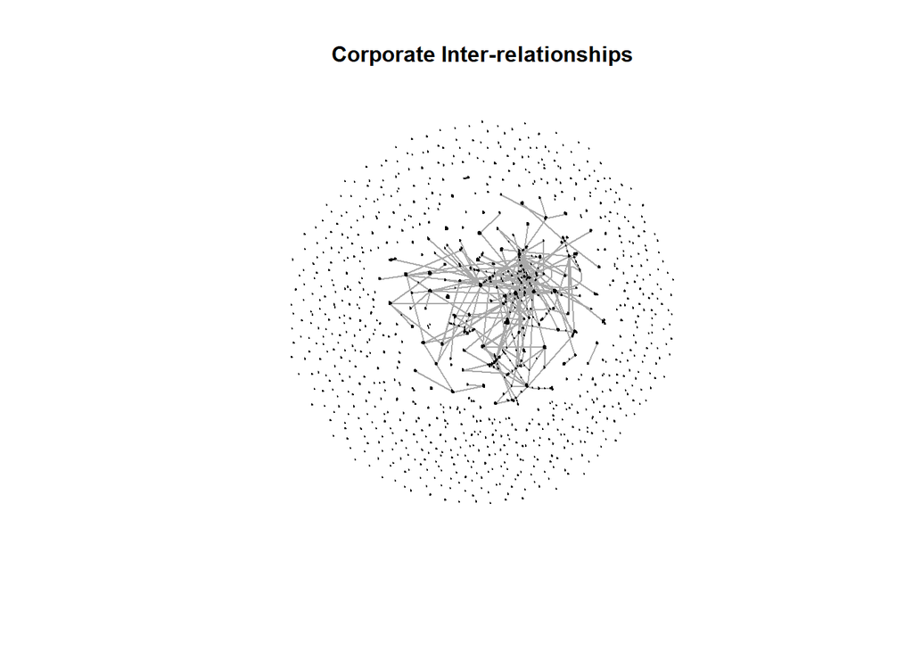

```r
V(eva)$size=.01
V(eva)$color=ifelse(V(eva)$csize<=50, "gray80", ifelse(V(eva)$csize<=100, "yellow", "darkred"))
V(eva)$label=NA
E(eva)$arrow.size=.001

set.seed(66)
plot(eva)
title("Corporate Inter-relationships", cex.main=1, col.main="black")
```

```r
# Graph #2: Big companies owning other big companies

vertice_big <- vertice[which(vertice$csize>40),]
summary(vertice_big)
```

```
##       from          name               csize
##  Min.   :   4   Length:29          Min.   : 41.0
##  1st Qu.:  18   Class :character   1st Qu.: 52.0
##  Median :  30   Mode  :character   Median : 76.0
##  Mean   :1357                      Mean   :110.2
##  3rd Qu.:3897                      3rd Qu.:130.0
##  Max.   :4370                      Max.   :552.0
```

```r
from <- as.data.frame(select(vertice_big, from))
to <- as.data.frame(select(vertice_big, from) %>% rename(to=from))

edge_big <- inner_join(from, edge)
edge_big <- inner_join(edge_big, to)
```

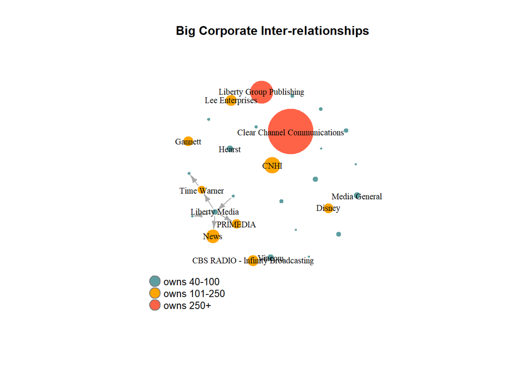

```r
eva2 <- graph.data.frame(edge_big, directed=T, vertices=vertice_big)
V(eva2)$size=V(eva2)$csize*.1
V(eva2)$frame.color <- "white"
V(eva2)$color=ifelse(V(eva2)$csize<=100, "cadetblue", ifelse(V(eva2)$csize<=250, "orange", "tomato"))
V(eva2)$label.cex=.7
V(eva2)$label=ifelse(V(eva2)$csize>80, V(eva2)$name, NA) # Do not show all labels - select which ones to show based on company size
V(eva2)$label.color="black"
E(eva2)$arrow.color="black"
E(eva2)$arrow.size=.5

set.seed(99)
plot(eva2, layout=layout_with_fr)
title("Big Corporate Inter-relationships", cex.main=1, col.main="black")
legend(x=-1.5, y=-1.1, c("owns 40-100", "owns 101-250", "owns 250+"), pch=21,col="#777777", pt.bg=c("cadetblue", "orange", "tomato"), pt.cex=2, cex=.8, bty="n", ncol=1)
```

```r
## Betweeness
sort(betweenness(eva2, directed=TRUE))
```

```
##                              AT&T                       Bertelsmann
##                                 0                                 0
##                              CNHI                            Disney
##                                 0                                 0
##                           Gannett                            Hearst
##                                 0                                 0
##                     Knight Ridder          Liberty Group Publishing
##                                 0                                 0
##         The McGraw-Hill Companies                     Media General
##                                 0                                 0
##                              News                    New York Times
##                                 0                                 0
##    Sinclair Broadcast Group (SBG)                              Sony
##                                 0                                 0
##                           Tribune                            Viacom
##                                 0                                 0
##                          PRIMEDIA                         Cox Radio
##                                 0                                 0
## CBS RADIO - Infinity Broadcasting              Emmis Communications
##                                 0                                 0
##                Warner Music Group                 Vivendi Universal
##                                 0                                 0
##      Clear Channel Communications    Landmark Communications (LCNI)
##                                 0                                 0
##                   Lee Enterprises                   MediaNews Group
##                                 0                                 0
##                 Kagan World Media                       Time Warner
##                                 0                                 2
##                     Liberty Media
##                                 5
```

```r
sort(degree(eva2, mode="out"))
```

```
##                       Bertelsmann                              CNHI
##                                 0                                 0
##                            Disney                           Gannett
##                                 0                                 0
##                            Hearst                     Knight Ridder
##                                 0                                 0
##          Liberty Group Publishing         The McGraw-Hill Companies
##                                 0                                 0
##                     Media General                              News
##                                 0                                 0
##                    New York Times    Sinclair Broadcast Group (SBG)
##                                 0                                 0
##                              Sony                           Tribune
##                                 0                                 0
##                          PRIMEDIA                         Cox Radio
##                                 0                                 0
## CBS RADIO - Infinity Broadcasting              Emmis Communications
##                                 0                                 0
##                Warner Music Group                 Vivendi Universal
##                                 0                                 0
##      Clear Channel Communications    Landmark Communications (LCNI)
##                                 0                                 0
##                   Lee Enterprises                   MediaNews Group
##                                 0                                 0
##                 Kagan World Media                              AT&T
##                                 0                                 1
##                       Time Warner                            Viacom
##                                 1                                 1
##                     Liberty Media
##                                 4
```

#### **2.3** Analysis

There are not too many big companies owning other big companies in this network - which is not too surprising.

There seems to be something interesting going on with the Liberty Media/Time Warner/Primedia/News(/Emmis/AT&T/Warner Music Group) group though: Compared to giants like Clear Channel and Liberty Group Publishing, these companies are seemingly “small” - but they are all “owned by each other”. Taken together, the seven companies in this group are the biggest group in the whole sample.

Breaking the group into smaller components could be strategic for many reasons. There could be fiscal implications, as well as implications for minority shareholders’ voting. Liberty Media seems to be the main “connector” between the pieces in this group (see betweeness and degree centrality measures). If I were to seek the underlying reason behind this disaggregation I would start my “investigation” at Liberty Media.

.